# Project 1: Wrangling, Exploration, Visualization

SDS322E

## Data Wrangling, Exploration, Visualization

### Bryan Giang

#### Introduction

For this dataset, I opted to work with data involving the NBA, particularly, player-focused data. This set of data are stats from the 2021-22 season, with very few games having been played. The second dataset involved in this process is a list of each NBA team’s salaries. My intention for choosing basketball data relates to my career aspirations. Over the summer, I had the pleasure of working with the Dallas Mavericks, and they provided me a diverse set of information that I had the freedom to manipulate and find insights from. Unfortunately, my R and general coding skills were not sufficient enough to fully explore all that I would have liked to. However, now having some experience from taking this class, I wanted to go back and explore data that I have a lot of familiarity with. I hope in working with NBA data, I can continue to hone my skills and knowledge for what would contribute to a career involving basketball–perhaps something like analytics or marketing. Through this data, I hope to find some early trends on different players, teams, and eventually carve out some datasets that answer a large question for me: Who should be getting the big bucks and who’s overpaid and underpaid?

```r
# read your datasets in here, e.g., with read_csv()
library(tidyverse)
player_data <- read_csv("/stor/home/bg26898/2021PlayerData.csv")
player_data <- player_data
team_records <- read_csv("/stor/home/bg26898/teamsalary.csv")
team_records <- team_records
```

#### Tidying: Reshaping

```r
library(tidyverse)
library(dplyr)

# renaming the Team column for team_records to have a common
# variable with player_data
abrev_team <- team_records %>% mutate(Team = recode(Team, `Chicago Bulls` = "CHI",
    `Atlanta Hawks` = "ATL", `Boston Celtics` = "BOS", `Brooklyn Nets` = "BRK",
    `Charlotte Hornets` = "CHO", `Cleveland Cavaliers` = "CLE",
    `Dallas Mavericks` = "DAL", `Denver Nuggets` = "DEN", `Detroit Pistons` = "DET",
    `Golden State Warriors` = "GSW", `Houston Rockets` = "HOU",
    `Indiana Pacers` = "IND", `Los Angeles Clippers` = "LAC",
    `Los Angeles Lakers` = "LAL", `Memphis Grizzlies` = "MEM",
    `Miami Heat` = "MIA", `Milwaukee Bucks` = "MIL", `Minnesota Timberwolves` = "MIN",
    `New Orleans Pelicans` = "NOP", `New York Knicks` = "NYK",
    `Oklahoma City Thunder` = "OKC", `Orlando Magic` = "ORL",
    `Philadelphia 76ers` = "PHI", `Phoenix Suns` = "PHO", `Portland Trail Blazers` = "POR",
    `Sacramento Kings` = "SAC", `San Antonio Spurs` = "SAS",
    `Toronto Raptors` = "TOR", `Utah Jazz` = "UTA", `Washington Wizards` = "WAS"))

# an example of long and wide pivot since the data was pretty
# tidy
long_data <- player_data %>% pivot_longer(cols = c("2P%", "3P%",
    "FT%"), names_to = "Shooting Splits", values_to = "Percentages")
long_data %>% pivot_wider(names_from = "Shooting Splits", values_from = "Percentages") %>%
    relocate("2P%", .after = "2PA") %>% relocate("3P%", .after = "3PA") %>%
    relocate("FT%", .after = "FTA")
```

```
## # A tibble: 403 x 30
##       Rk Player Pos     Age Tm        G    GS    MP    FG   FGA `FG%`  `3P`
##    <dbl> <chr>  <chr> <dbl> <chr> <dbl> <dbl> <dbl> <dbl> <dbl> <dbl> <dbl>
##  1     1 Preci… PF       22 TOR       4     4  26.3   4.3  10.5 0.405   0.5
##  2     2 Steve… C        28 MEM       3     3  30.7   5.7   9   0.63    0
##  3     3 Bam A… C        24 MIA       3     3  30.7   6.3  12.3 0.514   0
##  4     4 LaMar… C        36 BRK       3     0  20     4.7   7   0.667   0
##  5     5 Nicke… SG       23 NOP       4     4  33     6.3  16.3 0.385   2.8
##  6     6 Grays… SG       26 MIL       4     4  28.5   4.3  10.8 0.395   2.8
##  7     7 Jarre… C        23 CLE       4     4  31.3   7.8   9.3 0.838   0
##  8     8 Kyle … PF       28 MEM       3     0  19.3   1.7   8   0.208   0.7
##  9     9 Giann… PF       27 MIL       4     4  30     8.3  17.3 0.478   0.8
## 10    10 Thana… SF       29 MIL       4     1  17.8   2.5   3.8 0.667   0
## # … with 393 more rows, and 18 more variables: `3PA` <dbl>, `3P%` <dbl>,
## #   `2P` <dbl>, `2PA` <dbl>, `2P%` <dbl>, `eFG%` <dbl>, FT <dbl>, FTA <dbl>,
## #   `FT%` <dbl>, ORB <dbl>, DRB <dbl>, TRB <dbl>, AST <dbl>, STL <dbl>,
## #   BLK <dbl>, TOV <dbl>, PF <dbl>, PTS <dbl>
```

```r
# cleaning the rest of the data
clean_team <- abrev_team %>% select(-c(1, 4:ncol(abrev_team))) %>%
    na.omit() %>% rename(Team_Salary = 2) %>% mutate(Team_Salary = as.factor(gsub(",",
    "", Team_Salary))) %>% mutate(Team_Salary = as.numeric(gsub("\\$",
    " ", Team_Salary)))
head(clean_team)
```

```
## # A tibble: 6 x 2
##   Team  Team_Salary
##   <chr>       <dbl>
## 1 GSW     178242289
## 2 BRK     170450423
## 3 LAC     167940055
## 4 LAL     163850938
## 5 UTA     154707261
## 6 MIL     153928236
```

```r
clean_player <- player_data %>% select(-G, -GS) %>% rename(Team = Tm)
head(clean_player)
```

```
## # A tibble: 6 x 28
##      Rk Player Pos     Age Team     MP    FG   FGA `FG%`  `3P` `3PA`  `3P%`
##   <dbl> <chr>  <chr> <dbl> <chr> <dbl> <dbl> <dbl> <dbl> <dbl> <dbl>  <dbl>
## 1     1 Preci… PF       22 TOR    26.3   4.3  10.5 0.405   0.5   1.3  0.4
## 2     2 Steve… C        28 MEM    30.7   5.7   9   0.63    0     0   NA
## 3     3 Bam A… C        24 MIA    30.7   6.3  12.3 0.514   0     0   NA
## 4     4 LaMar… C        36 BRK    20     4.7   7   0.667   0     0.3  0
## 5     5 Nicke… SG       23 NOP    33     6.3  16.3 0.385   2.8   9    0.306
## 6     6 Grays… SG       26 MIL    28.5   4.3  10.8 0.395   2.8   8.8  0.314
## # … with 16 more variables: `2P` <dbl>, `2PA` <dbl>, `2P%` <dbl>, `eFG%` <dbl>,
## #   FT <dbl>, FTA <dbl>, `FT%` <dbl>, ORB <dbl>, DRB <dbl>, TRB <dbl>,
## #   AST <dbl>, STL <dbl>, BLK <dbl>, TOV <dbl>, PF <dbl>, PTS <dbl>
```

#### Joining/Merging

```r
glimpse(clean_team)  #30 observations, 2 variables
```

```
## Rows: 30
## Columns: 2
## $ Team        <chr> "GSW", "BRK", "LAC", "LAL", "UTA", "MIL", "POR", "BOS", "…
## $ Team_Salary <dbl> 178242289, 170450423, 167940055, 163850938, 154707261, 15…
```

```r
glimpse(clean_player)  #403 observations, 28 variables
```

```
## Rows: 403
## Columns: 28
## $ Rk     <dbl> 1, 2, 3, 4, 5, 6, 7, 8, 9, 10, 11, 12, 13, 14, 15, 16, 17, 18,…
## $ Player <chr> "Precious Achiuwa", "Steven Adams", "Bam Adebayo", "LaMarcus A…
## $ Pos    <chr> "PF", "C", "C", "C", "SG", "SG", "C", "PF", "PF", "SF", "PF", …
## $ Age    <dbl> 22, 28, 24, 36, 23, 26, 23, 28, 27, 29, 37, 21, 24, 34, 21, 21…
## $ Team   <chr> "TOR", "MEM", "MIA", "BRK", "NOP", "MIL", "CLE", "MEM", "MIL",…
## $ MP     <dbl> 26.3, 30.7, 30.7, 20.0, 33.0, 28.5, 31.3, 19.3, 30.0, 17.8, 26…
## $ FG     <dbl> 4.3, 5.7, 6.3, 4.7, 6.3, 4.3, 7.8, 1.7, 8.3, 2.5, 6.0, 5.0, 6.…
## $ FGA    <dbl> 10.5, 9.0, 12.3, 7.0, 16.3, 10.8, 9.3, 8.0, 17.3, 3.8, 11.7, 1…
## $ `FG%`  <dbl> 0.405, 0.630, 0.514, 0.667, 0.385, 0.395, 0.838, 0.208, 0.478,…
## $ `3P`   <dbl> 0.5, 0.0, 0.0, 0.0, 2.8, 2.8, 0.0, 0.7, 0.8, 0.0, 4.0, 2.3, 2.…
## $ `3PA`  <dbl> 1.3, 0.0, 0.0, 0.3, 9.0, 8.8, 0.0, 2.7, 2.8, 0.0, 6.0, 7.0, 7.…
## $ `3P%`  <dbl> 0.400, NA, NA, 0.000, 0.306, 0.314, NA, 0.250, 0.273, NA, 0.66…
## $ `2P`   <dbl> 3.8, 5.7, 6.3, 4.7, 3.5, 1.5, 7.8, 1.0, 7.5, 2.5, 2.0, 2.8, 3.…
## $ `2PA`  <dbl> 9.3, 9.0, 12.3, 6.7, 7.3, 2.0, 9.3, 5.3, 14.5, 3.8, 5.7, 6.8, …
## $ `2P%`  <dbl> 0.405, 0.630, 0.514, 0.700, 0.483, 0.750, 0.838, 0.188, 0.517,…
## $ `eFG%` <dbl> 0.429, 0.630, 0.514, 0.667, 0.469, 0.523, 0.838, 0.250, 0.500,…
## $ FT     <dbl> 1.5, 1.7, 5.0, 1.7, 2.0, 2.0, 1.5, 1.3, 7.3, 1.0, 1.7, 3.0, 2.…
## $ FTA    <dbl> 2.8, 1.7, 6.3, 2.7, 2.3, 2.0, 2.5, 1.3, 10.0, 1.3, 2.0, 3.8, 3…
## $ `FT%`  <dbl> 0.545, 1.000, 0.789, 0.625, 0.889, 1.000, 0.600, 1.000, 0.725,…
## $ ORB    <dbl> 2.8, 6.3, 3.0, 1.7, 2.3, 0.0, 1.8, 1.3, 1.8, 1.8, 1.3, 0.5, 2.…
## $ DRB    <dbl> 8.5, 6.7, 11.0, 3.7, 5.5, 4.0, 7.8, 4.0, 8.8, 2.8, 2.7, 7.5, 4…
## $ TRB    <dbl> 11.3, 13.0, 14.0, 5.3, 7.8, 4.0, 9.5, 5.3, 10.5, 4.5, 4.0, 8.0…
## $ AST    <dbl> 1.8, 4.7, 2.0, 0.3, 1.8, 2.0, 1.3, 1.7, 6.5, 1.0, 1.3, 5.8, 2.…
## $ STL    <dbl> 0.5, 1.0, 1.0, 0.3, 2.0, 1.0, 1.3, 1.0, 1.3, 0.5, 0.3, 1.0, 1.…
## $ BLK    <dbl> 0.0, 0.3, 0.3, 1.7, 0.8, 0.3, 0.8, 0.7, 1.8, 0.3, 0.7, 0.0, 0.…
## $ TOV    <dbl> 1.0, 2.3, 2.7, 1.0, 2.5, 0.5, 1.5, 0.0, 3.3, 1.3, 0.7, 2.8, 2.…
## $ PF     <dbl> 2.3, 1.7, 2.7, 2.3, 1.5, 1.3, 1.8, 1.3, 3.3, 3.0, 2.0, 2.8, 3.…
## $ PTS    <dbl> 10.5, 13.0, 17.7, 11.0, 17.3, 13.3, 17.0, 5.3, 24.5, 6.0, 17.7…
```

```r
joined_data <- left_join(clean_team, clean_player, by = "Team")
joined_data %>% summarize(n_distinct(Player))  #403 distinct observations
```

```
## # A tibble: 1 x 1
##   `n_distinct(Player)`
##                  <int>
## 1                  403
```

```r
intersect(clean_team$Team, clean_player$Team) %>% length
```

```
## [1] 30
```

```r
anti_join(clean_team, clean_player)  #0 rows not in common
```

```
## # A tibble: 0 x 2
## # … with 2 variables: Team <chr>, Team_Salary <dbl>
```

```r
anti_join(clean_player, clean_team)  #28 columns not in common, 0 rows
```

```
## # A tibble: 0 x 28
## # … with 28 variables: Rk <dbl>, Player <chr>, Pos <chr>, Age <dbl>,
## #   Team <chr>, MP <dbl>, FG <dbl>, FGA <dbl>, `FG%` <dbl>, `3P` <dbl>,
## #   `3PA` <dbl>, `3P%` <dbl>, `2P` <dbl>, `2PA` <dbl>, `2P%` <dbl>,
## #   `eFG%` <dbl>, FT <dbl>, FTA <dbl>, `FT%` <dbl>, ORB <dbl>, DRB <dbl>,
## #   TRB <dbl>, AST <dbl>, STL <dbl>, BLK <dbl>, TOV <dbl>, PF <dbl>, PTS <dbl>
```

First, it’s important to mention part of the process for tidying for this project. For the most part, the two datasets I worked with came in Tidy, so I created examples of long and wide pivots to demonstrate since it was not necessary for the original data sets. There were some details that needed to be cleaned out, and that involved renaming the teams (ex: Atlanta Hawks to ATL) to give common variables between the data sets. The team salaries data had salaries for future seasons, but for this project I just needed information for the 2021-22 season and removed the other years. To clean the players data set, I removed some columns that wouldn’t play a role in any of the calculations or summaries and renamed a column to create common variable names betweent the datasets so that we could join.

The clean_teams set had 30 observations, basically denoting that there are 30 NBA teams, while the clean_player set had 403 observations for the 403 players in the NBA. After a simple left join through the variable “Team”, we checked for distinct variables to see if any data was lost or gained, and the result was 403 distinct observations and 403 observations. We further checked this with anti_join and intersect to find rows, columns, and variables that existed between the datasets and those that were varied between the two.

#### Wrangling

```r
joined_data %>% group_by(Pos) %>% summarize_all(function(x) mean(!is.na(x))) %>%
    knitr::kable()  #computer proportion of NA's by position
```

| Pos | Team | Team_Salary | Rk | Player | Age | MP | FG | FGA | FG% | 3P | 3PA | 3P% | 2P | 2PA | 2P% | eFG% | FT | FTA | FT% | ORB | DRB | TRB | AST | STL | BLK | TOV | PF | PTS |
| --- | --- | --- | --- | --- | --- | --- | --- | --- | --- | --- | --- | --- | --- | --- | --- | --- | --- | --- | --- | --- | --- | --- | --- | --- | --- | --- | --- | --- |
| C | 1 | 1 | 1 | 1 | 1 | 1 | 1 | 1 | 0.9850746 | 1 | 1 | 0.5074627 | 1 | 1 | 0.9850746 | 0.9850746 | 1 | 1 | 0.8208955 | 1 | 1 | 1 | 1 | 1 | 1 | 1 | 1 | 1 |
| F | 1 | 1 | 1 | 1 | 1 | 1 | 1 | 1 | 0.6666667 | 1 | 1 | 0.6666667 | 1 | 1 | 0.3333333 | 0.6666667 | 1 | 1 | 0.3333333 | 1 | 1 | 1 | 1 | 1 | 1 | 1 | 1 | 1 |
| G | 1 | 1 | 1 | 1 | 1 | 1 | 1 | 1 | 0.5000000 | 1 | 1 | 0.5000000 | 1 | 1 | 0.5000000 | 0.5000000 | 1 | 1 | 0.0000000 | 1 | 1 | 1 | 1 | 1 | 1 | 1 | 1 | 1 |
| G-F | 1 | 1 | 1 | 1 | 1 | 1 | 1 | 1 | 1.0000000 | 1 | 1 | 0.0000000 | 1 | 1 | 1.0000000 | 1.0000000 | 1 | 1 | 1.0000000 | 1 | 1 | 1 | 1 | 1 | 1 | 1 | 1 | 1 |
| PF | 1 | 1 | 1 | 1 | 1 | 1 | 1 | 1 | 0.9506173 | 1 | 1 | 0.8271605 | 1 | 1 | 0.9259259 | 0.9506173 | 1 | 1 | 0.6543210 | 1 | 1 | 1 | 1 | 1 | 1 | 1 | 1 | 1 |
| PG | 1 | 1 | 1 | 1 | 1 | 1 | 1 | 1 | 1.0000000 | 1 | 1 | 0.9305556 | 1 | 1 | 0.9722222 | 1.0000000 | 1 | 1 | 0.6666667 | 1 | 1 | 1 | 1 | 1 | 1 | 1 | 1 | 1 |
| SF | 1 | 1 | 1 | 1 | 1 | 1 | 1 | 1 | 0.9397590 | 1 | 1 | 0.8554217 | 1 | 1 | 0.9036145 | 0.9397590 | 1 | 1 | 0.7349398 | 1 | 1 | 1 | 1 | 1 | 1 | 1 | 1 | 1 |
| SG | 1 | 1 | 1 | 1 | 1 | 1 | 1 | 1 | 0.9361702 | 1 | 1 | 0.8723404 | 1 | 1 | 0.9042553 | 0.9361702 | 1 | 1 | 0.6276596 | 1 | 1 | 1 | 1 | 1 | 1 | 1 | 1 | 1 |

```r
joined_data %>% group_by(Pos) %>% summarize_if(is.numeric, mean,
    na.rm = T) %>% knitr::kable()  #summarized mean of all players by positions
```

| Pos | Team_Salary | Rk | Age | MP | FG | FGA | FG% | 3P | 3PA | 3P% | 2P | 2PA | 2P% | eFG% | FT | FTA | FT% | ORB | DRB | TRB | AST | STL | BLK | TOV | PF | PTS |
| --- | --- | --- | --- | --- | --- | --- | --- | --- | --- | --- | --- | --- | --- | --- | --- | --- | --- | --- | --- | --- | --- | --- | --- | --- | --- | --- |
| C | 133080877 | 199.1493 | 26.89552 | 20.134328 | 3.471642 | 6.594030 | 0.5311364 | 0.4701493 | 1.367164 | 0.3300294 | 3.0074627 | 5.231343 | 0.5675758 | 0.5568939 | 1.5880597 | 2.1791045 | 0.7014545 | 1.9373134 | 4.710448 | 6.637313 | 1.228358 | 0.6985075 | 1.0014925 | 1.1731343 | 2.1552239 | 8.991045 |
| F | 138548777 | 248.3333 | 24.00000 | 8.333333 | 2.000000 | 3.333333 | 0.5625000 | 1.3333333 | 2.000000 | 0.6250000 | 0.6666667 | 1.333333 | 0.5000000 | 0.7815000 | 0.3333333 | 0.6666667 | 0.5000000 | 0.0000000 | 2.000000 | 2.000000 | 0.000000 | 0.3333333 | 0.3333333 | 0.0000000 | 0.3333333 | 5.666667 |
| G | 136561064 | 98.0000 | 21.00000 | 7.000000 | 1.500000 | 2.500000 | 0.6000000 | 0.5000000 | 1.500000 | 0.3330000 | 1.0000000 | 1.000000 | 1.0000000 | 0.7000000 | 0.0000000 | 0.0000000 | NaN | 0.0000000 | 1.000000 | 1.000000 | 1.000000 | 0.5000000 | 0.0000000 | 0.0000000 | 1.0000000 | 3.500000 |
| G-F | 167940055 | 49.0000 | 20.00000 | 9.000000 | 1.000000 | 3.000000 | 0.3330000 | 0.0000000 | 0.000000 | NaN | 1.0000000 | 3.000000 | 0.3330000 | 0.3330000 | 1.0000000 | 2.0000000 | 0.5000000 | 0.0000000 | 1.000000 | 1.000000 | 1.000000 | 0.0000000 | 0.0000000 | 0.0000000 | 1.0000000 | 3.000000 |
| PF | 134642784 | 217.5062 | 26.12346 | 18.497531 | 2.965432 | 6.491358 | 0.4464675 | 0.8098765 | 2.404938 | 0.3222687 | 2.1530864 | 4.090123 | 0.4951733 | 0.5140130 | 1.1975309 | 1.6209877 | 0.7391321 | 0.9444444 | 3.217284 | 4.161728 | 1.356790 | 0.6246914 | 0.3864198 | 0.9567901 | 1.4444444 | 7.923457 |
| PG | 131997504 | 215.2222 | 26.48611 | 21.977778 | 3.629167 | 8.884722 | 0.3917778 | 1.2680556 | 3.762500 | 0.3375075 | 2.3666667 | 5.134722 | 0.4208857 | 0.4634306 | 1.2680556 | 1.5777778 | 0.7638750 | 0.4388889 | 2.440278 | 2.875000 | 3.848611 | 0.9319444 | 0.2916667 | 1.7958333 | 1.5152778 | 9.777778 |
| SF | 137987232 | 182.4458 | 25.72289 | 19.419277 | 3.139759 | 7.025301 | 0.4450641 | 1.0445783 | 3.033735 | 0.3048873 | 2.1012048 | 3.998795 | 0.5322267 | 0.5193205 | 1.0301205 | 1.4036145 | 0.6891639 | 0.6445783 | 2.775904 | 3.410843 | 1.454217 | 0.6373494 | 0.3132530 | 1.0831325 | 1.6132530 | 8.339759 |
| SG | 136263027 | 200.1702 | 25.17021 | 19.145745 | 3.188298 | 7.597872 | 0.3981136 | 1.3500000 | 3.796809 | 0.3335488 | 1.8425532 | 3.808511 | 0.4492471 | 0.4846477 | 1.1010638 | 1.3244681 | 0.8304746 | 0.4436170 | 2.036170 | 2.479787 | 1.830851 | 0.6436170 | 0.2085106 | 1.0978723 | 1.4085106 | 8.813830 |

```r
joined_data %>% group_by(Team, Player) %>% summarize_all(mean,
    na.rm = T) %>% slice_max(PTS, n = 1) %>% head() %>% knitr::kable()  #who is the highest scoring player per team
```

| Team | Player | Team_Salary | Rk | Pos | Age | MP | FG | FGA | FG% | 3P | 3PA | 3P% | 2P | 2PA | 2P% | eFG% | FT | FTA | FT% | ORB | DRB | TRB | AST | STL | BLK | TOV | PF | PTS |
| --- | --- | --- | --- | --- | --- | --- | --- | --- | --- | --- | --- | --- | --- | --- | --- | --- | --- | --- | --- | --- | --- | --- | --- | --- | --- | --- | --- | --- |
| ATL | Trae Young | 134222983 | 400 | NA | 23 | 33.3 | 9.0 | 19.7 | 0.458 | 1.7 | 5.3 | 0.313 | 7.3 | 14.3 | 0.512 | 0.500 | 5.3 | 5.3 | 1.000 | 0.0 | 2.3 | 2.3 | 10.0 | 1.3 | 0.0 | 3.0 | 1.0 | 25.0 |
| BOS | Jaylen Brown | 142524201 | 62 | NA | 25 | 37.3 | 10.3 | 21.0 | 0.492 | 3.7 | 9.3 | 0.393 | 6.7 | 11.7 | 0.571 | 0.579 | 4.0 | 5.3 | 0.750 | 1.0 | 6.3 | 7.3 | 3.0 | 2.0 | 0.7 | 4.0 | 3.3 | 28.3 |
| BRK | Kevin Durant | 170450423 | 110 | NA | 33 | 34.5 | 12.0 | 21.5 | 0.558 | 1.8 | 5.3 | 0.333 | 10.3 | 16.3 | 0.631 | 0.599 | 5.3 | 6.8 | 0.778 | 1.0 | 8.8 | 9.8 | 5.8 | 1.0 | 0.8 | 1.8 | 1.0 | 31.0 |
| CHI | Zach LaVine | 135725596 | 219 | NA | 26 | 33.8 | 8.8 | 17.5 | 0.500 | 3.0 | 6.8 | 0.444 | 5.8 | 10.8 | 0.535 | 0.586 | 5.0 | 5.3 | 0.952 | 0.3 | 5.0 | 5.3 | 4.8 | 0.5 | 0.5 | 3.0 | 1.0 | 25.5 |
| CHO | Miles Bridges | 114436800 | 56 | NA | 23 | 35.3 | 9.3 | 17.5 | 0.529 | 2.5 | 7.0 | 0.357 | 6.8 | 10.5 | 0.643 | 0.600 | 4.0 | 4.3 | 0.941 | 2.5 | 6.0 | 8.5 | 2.3 | 2.3 | 0.5 | 1.5 | 3.0 | 25.0 |
| CLE | Collin Sexton | 133083218 | 339 | NA | 23 | 29.0 | 7.3 | 14.8 | 0.492 | 1.8 | 5.0 | 0.350 | 5.5 | 9.8 | 0.564 | 0.551 | 2.8 | 4.0 | 0.688 | 0.5 | 1.8 | 2.3 | 2.3 | 0.5 | 0.0 | 2.0 | 3.8 | 19.0 |

```r
joined_data %>% group_by(Team) %>% summarize(mean_age = mean(Age)) %>%
    slice_min(mean_age, n = 5) %>% knitr::kable()  #mean age of each team, let's look at 5 youngest teams
```

| Team | mean_age |
| --- | --- |
| OKC | 23.13333 |
| ORL | 23.90909 |
| MEM | 24.00000 |
| MIN | 24.13333 |
| DET | 24.57143 |

```r
# team contribution, how much does each player contribute to
# their overall team in terms of points, minutes, blocks
# assist in percentages
team_data <- joined_data %>% group_by(Team) %>% summarize(team_points = sum(PTS),
    team_rebounds = sum(TRB), team_blocks = sum(BLK), team_assist = sum(AST),
    team_minutes = sum(MP))
head(team_data) %>% knitr::kable()
```

| Team | team_points | team_rebounds | team_blocks | team_assist | team_minutes |
| --- | --- | --- | --- | --- | --- |
| ATL | 121.8 | 56.0 | 6.0 | 27.2 | 266.1 |
| BOS | 148.5 | 63.2 | 12.2 | 29.2 | 316.3 |
| BRK | 111.2 | 51.4 | 7.7 | 21.9 | 259.4 |
| CHI | 109.9 | 42.3 | 7.6 | 25.0 | 246.0 |
| CHO | 128.3 | 52.2 | 4.7 | 30.7 | 273.3 |
| CLE | 116.2 | 46.9 | 5.0 | 34.0 | 266.4 |

```r
team_contribution <- left_join(joined_data, team_data) %>% group_by(Team,
    Player) %>% summarize(average_MP = MP/team_minutes, average_points = PTS/team_points,
    average_blocks = BLK/team_blocks, average_assist = AST/team_assist,
    average_rebounds = TRB/team_rebounds)
head(team_contribution) %>% knitr::kable()
```

| Team | Player | average_MP | average_points | average_blocks | average_assist | average_rebounds |
| --- | --- | --- | --- | --- | --- | --- |
| ATL | Bogdan Bogdanović | 0.0977076 | 0.0821018 | 0.0000000 | 0.0625000 | 0.0482143 |
| ATL | Cam Reddish | 0.0950770 | 0.1535304 | 0.0000000 | 0.0257353 | 0.0767857 |
| ATL | Clint Capela | 0.0928222 | 0.0714286 | 0.2833333 | 0.0110294 | 0.2089286 |
| ATL | De’Andre Hunter | 0.1108606 | 0.0944171 | 0.1666667 | 0.0367647 | 0.0535714 |
| ATL | Delon Wright | 0.0574972 | 0.0164204 | 0.0000000 | 0.0845588 | 0.0714286 |
| ATL | Gorgui Dieng | 0.0612552 | 0.0550082 | 0.1166667 | 0.0625000 | 0.1553571 |

```r
con <- left_join(team_contribution, clean_team) %>% group_by(Player,
    Team) %>% mutate(player_con = sum(c_across(average_MP:average_rebounds),
    na.rm = T))
head(con) %>% knitr::kable()
```

| Team | Player | average_MP | average_points | average_blocks | average_assist | average_rebounds | Team_Salary | player_con |
| --- | --- | --- | --- | --- | --- | --- | --- | --- |
| ATL | Bogdan Bogdanović | 0.0977076 | 0.0821018 | 0.0000000 | 0.0625000 | 0.0482143 | 134222983 | 0.2905237 |
| ATL | Cam Reddish | 0.0950770 | 0.1535304 | 0.0000000 | 0.0257353 | 0.0767857 | 134222983 | 0.3511284 |
| ATL | Clint Capela | 0.0928222 | 0.0714286 | 0.2833333 | 0.0110294 | 0.2089286 | 134222983 | 0.6675421 |
| ATL | De’Andre Hunter | 0.1108606 | 0.0944171 | 0.1666667 | 0.0367647 | 0.0535714 | 134222983 | 0.4622805 |
| ATL | Delon Wright | 0.0574972 | 0.0164204 | 0.0000000 | 0.0845588 | 0.0714286 | 134222983 | 0.2299049 |
| ATL | Gorgui Dieng | 0.0612552 | 0.0550082 | 0.1166667 | 0.0625000 | 0.1553571 | 134222983 | 0.4507872 |

```r
calculated_salary <- con %>% group_by(Team, Player, Team_Salary) %>%
    summarize(total_con = player_con/5) %>% summarize(calc_salary = total_con *
    Team_Salary)
head(calculated_salary) %>% knitr::kable()
```

| Team | Player | calc_salary |
| --- | --- | --- |
| ATL | Bogdan Bogdanović | 7798992 |
| ATL | Cam Reddish | 9425901 |
| ATL | Clint Capela | 17919899 |
| ATL | De’Andre Hunter | 12409732 |
| ATL | Delon Wright | 6171705 |
| ATL | Gorgui Dieng | 12101200 |

#### Visualizing

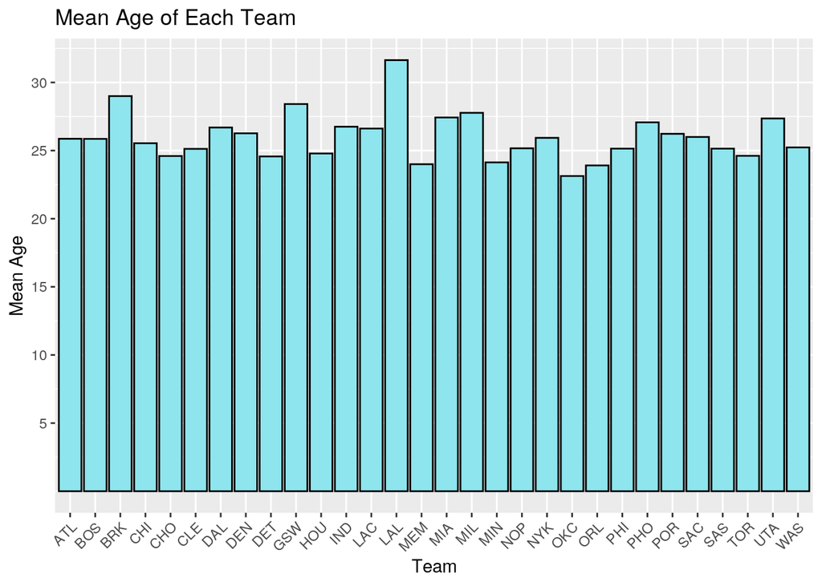

```r
joined_data %>% group_by(Team) %>% summarize(mean_age = mean(Age)) %>%
    ggplot(aes(x = Team, y = mean_age)) + geom_bar(aes(y = mean_age),
    stat = "summary", fun = mean, color = "black", fill = "cadetblue2") +
    theme(axis.text.x = element_text(angle = 45, hjust = 1),
        legend.position = "none") + scale_y_continuous(breaks = seq(5,
    40, 5)) + ggtitle("Mean Age of Each Team") + xlab("Team") +
    ylab("Mean Age")
```

Plot 1 is a visual of the mean ages calculated earlier. This is the mean age of each of the 30 NBA teams with their players. The most apparent trend, that requires a bit of outside knowledge, is the fact that all the contending NBA championship teams are on the older-end. That includes the LA Lakers, BRK Nets, MIA Heat, MIL Bucks, UTA Jazz, PHO Suns–all teams that had deep playoff runs last year. In the NBA, if you’re not contending for a championship, you’re typically rebuilding, which is denoted by picking up a lot of young talent.

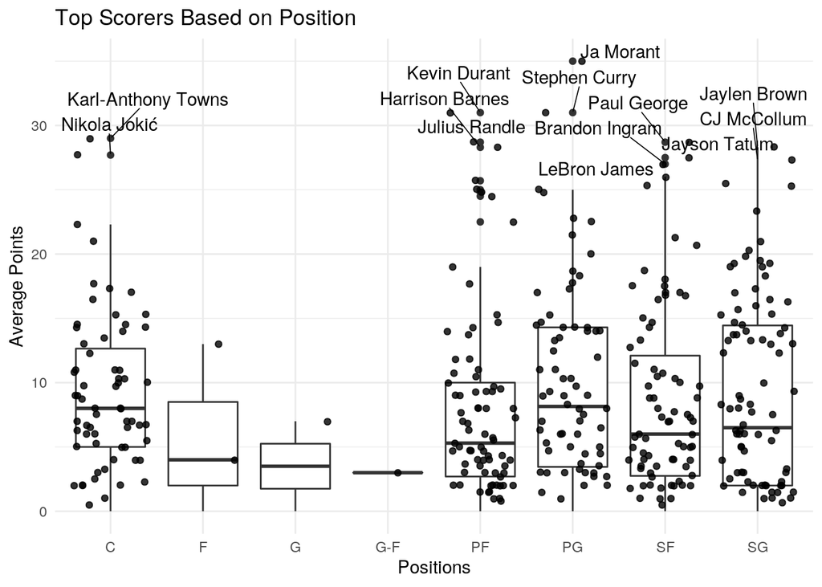

```r
library(ggrepel)
joined_data %>% ggplot(aes(x = Pos, y = PTS)) + geom_boxplot() +
    geom_jitter(data = joined_data %>% filter(PTS > 0), alpha = 0.8) +
    geom_text_repel(aes(label = ifelse(PTS > quantile(joined_data$PTS,
        0.97, na.rm = T), as.character(Player), "")), nudge_y = 2,
        segment.size = 0.3) + theme_minimal() + ggtitle("Top Scorers Based on Position") +
    xlab("Positions") + ylab("Average Points")
```

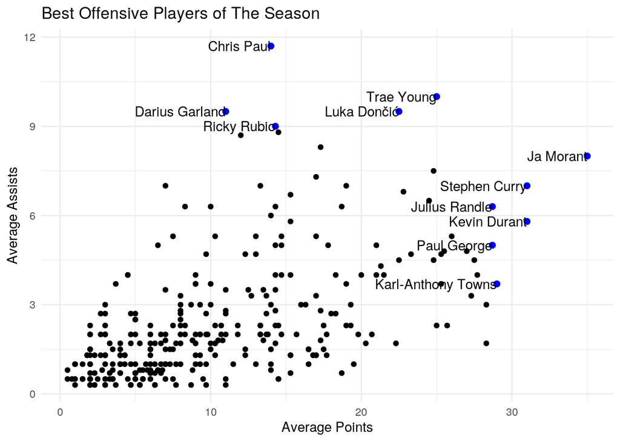

```r
top_score <- clean_player %>% slice_max(PTS, n = 5)
top_pass <- clean_player %>% slice_max(AST, n = 5)
clean_player %>% filter(PTS > 0 & AST > 0) %>% ggplot(aes(x = PTS,
    y = AST)) + geom_point() + geom_point(data = top_score, aes(x = PTS,
    y = AST), color = "blue", size = 2) + geom_point(data = top_pass,
    aes(x = PTS, y = AST), color = "blue", size = 2) + geom_text(data = top_score,
    aes(label = Player), hjust = 1) + geom_text(data = top_pass,
    aes(label = Player), hjust = 1) + theme_minimal() + ggtitle("Best Offensive Players of The Season") +
    xlab("Average Points") + ylab("Average Assists")
```

[output not shown]